# Les médias et les facteurs sociodémographiques, des variables clés aux expositions des théories complotistes

# **Introduction**

Cette analyse s’appuiera sur une étude menée par l’[ARCOM](https://www.arcom.fr/) (Autorité de régulation de la communication audiovisuelle et numérique) intitulée “Les Français et l’information”. Cette étude repose sur des questions à choix simples ou multiples relatives aux sujet de l’information.

En France, et plus précisément en 2025, l’information est **omniprésente** dans notre quotidien. Elle émane de diverses sources : la télévision, la radio, la presse écrite (revues, journaux), les médias indépendants, les plateformes numériques, ou encore les échanges interpersonnels. Les centres d’intérêt des individus sont variés, et chacun accorde une importance singulière à l’actualité. Cependant, cette **exposition massive** peut se révéler problématique pour certains, notamment par la diffusion de fausses informations, de **théories complotistes** ou de contenus manipulateurs.

*C’est pourquoi on va se demander dans notre étude si la croyance et l’exposition aux théories complotistes varient en fonction des médias consultés, de variables sociodémographiques et des convictions politiques.*

Nous étudierons dans un premier temps le lien entre la croyance aux théories complotistes et plusieurs facteurs sociodémographiques, puis les variations d’exposition en fonction des médias. L’étude se terminera par un apparté politique et la conclusion général.

## **Les thématiques d’Analyse**

### **Les Variables étudiés**

Pour ce faire, nous articulerons notre analyse autour des thématiques suivantes :

- **Profil sociodémographique :**
  - Le sexe
  - Le niveau d’étude
  - L’âge
- **Nature des médias consultés :**
  - La presse écrite (journaux)
  - La télévision :
    - Les chaînes nationales (généralistes)
    - Les chaînes d’information en continu
  - Les médias indépendants
- **Les théories complotistes<sup>1</sup>** (croyance mesurée sur quelques thématiques clés)
- **Les convictions politiques**

### **Les théories complotistes**

**L’enquête sur ce sujet porte sur 8 théories :**

- *Les Américains n’ont jamais marché sur la lune*
- *L’épidémie Covid s’est répandue accidentellement depuis la ville de Wuhan en Chine*
- *Il existe un complot juif à l’échelle mondiale*
- *C’est la CIA qui a abattu les tours jumelles à New York le 11 septembre*
- *Le gouvernement est de mèche avec l’industrie pharmaceutique pour cacher la nocivité des vaccins*
- *Lady Diana est décédée dans un accident de voiture sous le Pont de l’Alma*
- *Le réchauffement climatique actuel n’est pas causé par l’homme*
- *Donald Trump est le véritable vainqueur des dernières élections américaines*

À partir de ces 8 théories, les questions posées sont :

- L’avez-vous lue, vue ou entendue ?
- Pensez-vous que cela est exact ?

Ainsi, pour créer une analyse pertinente et éviter d’étudier les théories une par une, nous allons créer **deux variables** qui renvoient, pour chaque répondant, une valeur entre 0 et 10 (0 correspondant à une exposition à aucune de ces théories et 10 à toutes les théories) :

- Avec la première variable relative au fait d’avoir déja été exposé aux théories;
- Et la deuxième lièes à la croyance à ces théories.

# **Variables sociodémographiques et croyance en théorie complotiste**

Nous allons commencer par examiner comment les *variables sociodémographiques* peuvent avoir un impact sur la croyance en ces théories.

Pour ce faire, nous allons étudier le *genre*, le *niveau d’études* et l’*âge*.

## **Le genre**

Pour la comparaison entre *les femmes* et *les hommes*, on va construire un histogramme pour chaque genre.

Cependant, les femmes représentent 55.5 % des répondants, ainsi un histogramme de fréquence ne serait pas intéressant étant donné la présence plus importante des femmes parmi les répondants aux sondages.

Ainsi, on va représenter cet histogramme en **densité**.

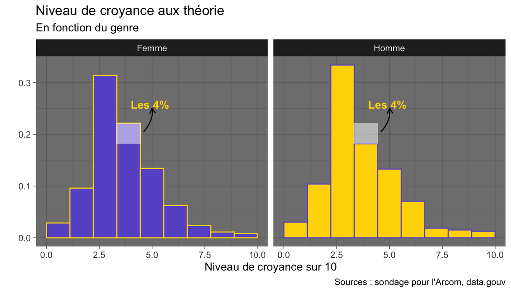

Il n’existe **pas de différences significatives entre les deux distributions**, seules des différences précises sont à énoncer.

Quelques tendances révélées par les graphiques :

- Un pic plus élevé des hommes pour un niveau de croyance d’environ 25 % des théories.
- Une différence d’environ **4 %** pour les femmes pour une croyance de 4 théories sur 10.
- Les hommes croientt d’avantage pour plus de 8 théories sur 10.

## **Niveau d’étude**

Dans un premier temps, on va présenter **la répartition des niveaux scolaires des répondants**, cela nous permettra d’introduire dans un tableau **une comparaison des croyances aux théories complotistes en fonction du niveau d’étude**, afin que, par la suite, soit effectué un **test de comparaison à la moyenne** pour voir s’il existe des **différences significatives en fonction du niveau d’étude**.

### **Répartition des niveaux scolaires**

Les niveaux scolaires des répondants aux sondages sont :

- Niveau avant ou équivalent au baccalauréat :
  - Niveau primaire
  - Collège
  - Lycée
  - Technique court
  - Baccalauréat
- Niveau post-bac :
  - Technique supérieure
  - Supérieur 1<sup>er</sup> cycle
  - Supérieur 2<sup>ème</sup> cycle
  - Supérieur 3<sup>ème</sup> cycle

Le niveau scolaire le plus représenté est le **baccalauréat**, représentant 24.4 % des répondants.  
Les diplômés du supérieur représentent au total 45.01 % des participants interrogés par le sondage, avec un effectif total de **1506** individus, le reste disposant d’un niveau scolaire inférieur ou égal au baccalauréat.

On constate donc que le sondage a voulu assurer une certaine **hétérogénéité** en terme de niveau scolaire des répondants afin de disposer d’échantillons pouvant être étudiés.

### **Niveau d’étude et théories complotistes: analyse par tableaux de proportion**

À l’inverse de l’étude sur le genre, on va utiliser une variable de croyance qui sera **codée de 0 à 8** et qui dénombre précisément **le nombre de théories auxquelles les protagonistes croient**.

- La construction d’un tableau présentant la répartition des croyances aux théories complotistes permet d’arriver à la conclusion suivante :
  - **Pour l’ensemble des niveaux d’éducation (hormis le collège), la part la plus importante est celle des répondants croyant à 2 théories sur 8**.

Cette conclusion est claire, mais elle ne permet pas de répondre au sujet, qui est *“est-ce que le niveau de diplôme a un impact sur la croyance aux théories complotistes”*.

Ainsi, pour répondre à la problématique, on va réunir en une seule catégorie les individus qui croient à 4 théories ou plus afin d’obtenir un résultat parlant.

Nombre de théories adhérées en fonction du niveau d’étucation

|  | 0 | 1 | 2 | 3 | Plus de 4 complots |
| --- | --- | --- | --- | --- | --- |
| **Sans/Peu diplomé** |  |  |  |  |  |
| Niveau primaire | 0.03 | 0.10 | 0.22 | 0.21 | 0.44 |
| Collège | 0.05 | 0.07 | 0.24 | 0.28 | 0.37 |
| **Secondaire** |  |  |  |  |  |
| lycèe | 0.03 | 0.09 | 0.36 | 0.23 | 0.29 |
| Tech court | 0.03 | 0.09 | 0.28 | 0.23 | 0.37 |
| Baccalauréats | 0.04 | 0.11 | 0.31 | 0.24 | 0.29 |
| **Supérieur court** |  |  |  |  |  |
| Tech sup | 0.03 | 0.10 | 0.38 | 0.26 | 0.23 |
| Sup 1er cycle | 0.04 | 0.13 | 0.43 | 0.18 | 0.22 |
| **Supérieur long** |  |  |  |  |  |
| Sup 2ème cycle | 0.02 | 0.15 | 0.49 | 0.18 | 0.16 |
| Sup 3ème cycle | 0.04 | 0.16 | 0.47 | 0.18 | 0.15 |

- Ce tableau nous permet donc de pouvoir constater les tendances que l’on recherchait :
  - **Plus le niveau d’étude de l’individu augmente, moins il croit aux théories complotistes**.
  - En effet, pour un niveau de diplôme inférieur ou égal au baccalauréat, la part est supérieure ou égale à 29%, et pour les diplômés supérieurs au baccalauréat, la part est inférieure ou égale à 23%.
  - Différences marquantes entre les catégories de diplômés les plus éloignées : 44% des individus au niveau primaire croient à au moins 4 théories contre seulement 15% des diplômés du supérieur 3<sup>ème</sup> cycle.

### **Niveau d’étude et théories complotistes: analyse par test de moyenne**

Afin d’étayer la conclusion présentée précédemment, nous procédons à un **test de conformité d’une espérance à un standard** pour chaque **niveau d’études**.

où $\mu_0$ correspond à la **moyenne globale du niveau de croyances aux théories complotistes**.

#### **Méthodologie**

Les **hypothèses statistiques** associées au test de conformité sont définies comme suit :

$$\begin{cases}
H_0 : \mu = \mu_0 \\
H_1 : \mu \neq \mu_0
\end{cases}$$

Le **seuil de signification** est fixé à : $\alpha = 5\%$

#### **Présentation du tableau**

Le tableau présente **la taille de l’échantillon**, **la moyenne globale servant de standard**, **la moyenne estimée pour chacun des échantillons**, ainsi que **la p-value<sup>1</sup>** associée au test statistique.

La *p-value (probabilité critique)* correspond à la valeur limite du seuil de signification $\alpha$ pour laquelle l’hypothèse nulle $H_0$ serait rejetée compte tenu des observations. Plus la valeur de la p-value est faible, plus la probabilité de commettre une erreur en rejetant l’hypothèse nulle est réduite.

Lorsque la **moyenne de l’échantillon** est affichée en **rouge**, cela indique qu’elle est **supérieure au standard**, tandis qu’un affichage en **bleu** signifie qu’elle est **inférieure au standard**.

De même, une **p-value affichée en rouge** conduit au **rejet de l’hypothèse nulle $H_0$** (p-value $< 0{,}025$), alors qu’une **p-value affichée en gris** indique que l’on **ne peut pas rejeter l’hypothèse nulle** (p-value $> 0{,}025$).

#### **Le test**

|  | Effectif | moyenne | mean of x | p-value |
| --- | --- | --- | --- | --- |
| **Sans/Peu diplomé** |  |  |  |  |
| Niveau primaire | 77 | 3.5 | 4.35 | 0.003113 |
| Collège | 167 | 3.5 | 3.99 | 0.002839 |
| **Secondaire** |  |  |  |  |
| lycèe | 213 | 3.5 | 3.60 | 0.472304 |
| Tech court | 566 | 3.5 | 3.87 | 0.000007 |
| Baccalauréats | 817 | 3.5 | 3.58 | 0.259032 |
| **Supérieur court** |  |  |  |  |
| Tech sup | 525 | 3.5 | 3.36 | 0.035268 |
| Sup 1er cycle | 423 | 3.5 | 3.24 | 0.002655 |
| **Supérieur long** |  |  |  |  |
| Sup 2ème cycle | 458 | 3.5 | 3.09 | 0.000000 |
| Sup 3ème cycle | 100 | 3.5 | 2.91 | 0.000251 |

#### **Conclusion du test**

Par ailleurs, pour les **diplômés de l’enseignement supérieur**, la moyenne estimée est inférieure au standard. À l’inverse, pour les autres niveaux d’études, les moyennes estimées sont supérieures au standard.

#### **Interprétation**

Les résultats issus de ce test vont dans le **même sens que les précédents**. En effet, les **moyennes du niveau de croyances aux théories complotistes** observées chez les *moins diplômés* sont **plus élevées** que celles des *plus diplômés*.

On peut ainsi conclure que les **individus les moins diplômés ont tendance à adhérer davantage aux théories complotistes** que les individus les plus diplômés.

## **L’ Âge**

Pour l’étude sur l’âge, nous reprenons notre variable de niveau de croyance de départ, codée de 0 à 10.

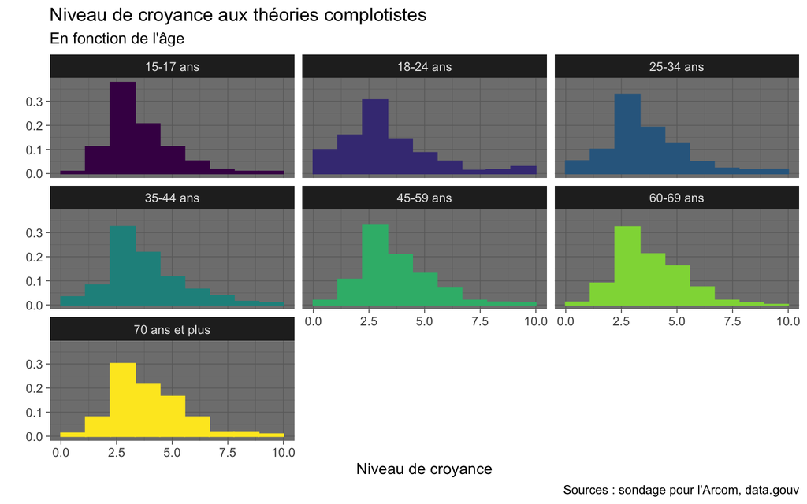

- Les tendances montrent que :
  - pour **les plus jeunes**, le niveau de croyances aux théories complotistes est **plus faible**. En effet, les fonctions de densité des plus jeunes sont plus importantes pour de faibles niveaux de croyance.
  - À l’inverse, à partir de **60 ans**, on constate que les densités sont bien plus élevées pour des niveaux de croyances **plus élevés**.
  - On peut le constater également avec les moyennes : (*3.07* pour les 18-24ans ans, *3.74* pour les 70 ans et plus).

**On semble arriver à montrer que plus l’âge augmente, plus le niveau de croyance augmente.**

- En étudiant plus précisément les théories, on a pu découvrir un fait assez original auquel on pouvait s’attendre.

Le réchauffement climatique n’est pas causé par l’homme

|  | adhèsion | refus |
| --- | --- | --- |
| 15-17 ans | 15.24 | 84.76 |
| 18-24 ans | 18.02 | 81.98 |
| 25-34 ans | 17.63 | 82.37 |
| 35-44 ans | 23.39 | 76.61 |
| 45-59 ans | 22.56 | 77.44 |
| 60-69 ans | 22.63 | 77.37 |
| 70 ans et plus | 30.31 | 69.69 |

[figure not shown]

# **Les théories complotistes, une croyance plus ou moins développé selon le canal d’information utilisé**

Après avoir abordé les **déterminants individuels**, intéressons-nous désormais aux **facteurs liés aux pratiques médiatiques**.

En effet, les médias constituent un *vecteur majeur* d’exposition aux **théories complotistes**.

Nous étudierons donc, dans cette partie, le rôle des **réseaux d’information** dans la *diffusion* des théories complotistes.

## **L’ ensemble des médias étudiés**

Dans le cadre de l’analyse des **mécanismes de diffusion de l’information**, il est nécessaire d’examiner la **diversité des médias** qui constituent l’*environnement informationnel* de notre projet.

Les médias, qu’ils soient **traditionnels** ou **numériques**, représentent des *systèmes structurés*. Leur organisation influence directement la manière dont les individus perçoivent et interprètent l’information à laquelle ils sont exposés.

Cette partie vise donc à établir une **typologie objective** des différents médias, dans le but de fournir une **base solide** pour l’étude de leur impact sur la **propagation** et les **représentations** que font les individus à l’égard des *« fakes news »*.

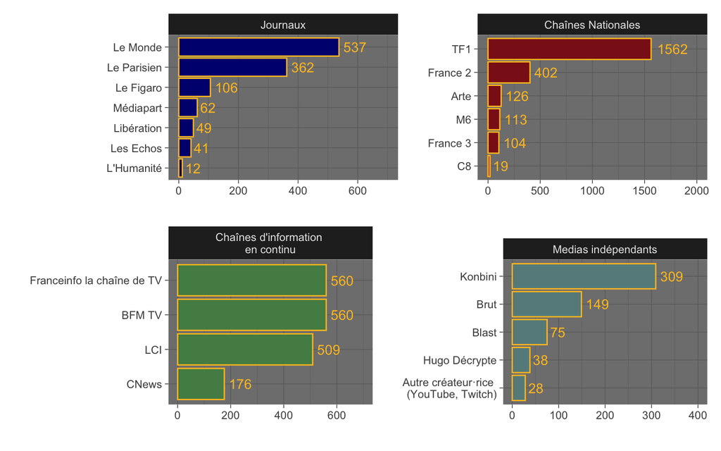

Nous présentons ci-dessus les **différents médias** utilisés dans l’étude réalisée par l’ARCOM. Il apparaît que les **médias indépendants** ne constituent qu’une *proportion très faible* de l’ensemble des canaux analysés. En effet, ces derniers représentent **10.15%**.

Pour cette raison, les sections suivantes se concentreront principalement sur les **journaux** ainsi que sur les **chaînes nationales**. Ces deux catégories de médias offrent une représentation *suffisamment pertinente* de leur secteur respectif et présentent des **lignes éditoriales plus développées** que celles proposées par les **chaînes d’information en continu**, malgré le fait que cette dernière représente **30.6%**.

## **L’ exposition des narratifs conspirationnistes au coeur des médias**

Après avoir identifié chaque média qui composait notre sujet, il nous semble intéressant de débuter par l’étude simultanée des châines publiques et de la presse

**Afin d’en présenter les effets**, nous construirons deux *diagrammes de densité* permettant d’analyser les résultats en fonction de notre **variable de niveau d’exposition**.  
Celle-ci s’étend de **0**, correspondant à une personne n’ayant **jamais entendu de théorie**, à **10**, correspondant à un individu ayant déjà été exposé à **l’ensemble de ces mythes**.

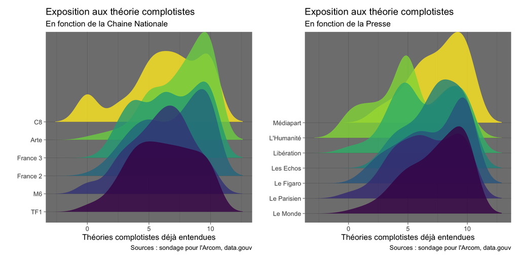

#### **Les chaînes publiques**

Nous pouvons observer la distribution de l’exposition aux théories complotistes déjà entendues par les téléspectateurs des différentes chaînes nationales (1<sup>er</sup> graphique)  
Il est important de rappeler que le fait d’avoir déjà entendu une *fake news* ne reflète en rien l’adhésion à celle-ci.

Ainsi, une chaîne comme **Arte** présente un pic relativement marqué (autour de 8 à 10 théories déjà entendues) et une variabilité plus faible que les autres. Cette situation peut s’expliquer par la diffusion régulière de documentaires visant, dans certains cas, à informer, contextualiser ou déconstruire ces théories. Cela traduit davantage une **connaissance** de ces fausses informations qu’une croyance en leur véracité.

À l’inverse, **C8** présente une variabilité plus élevée et un pic moins net qu’Arte. Elle reflète plutôt une exposition diversifiée et plus importante aux théories complotistes.

#### **La presse**

Ces observations montrent que l’exposition aux théories complotistes varie sensiblement selon les médias écrits (2<sup>ème</sup> graphique)  
**Mediapart** apparaît comme le média où l’exposition est la plus élevée, ce qui pourrait s’expliquer par une démarche éditoriale axée sur l’enquête, l’analyse approfondie et la déconstruction d’affirmations douteuses.

À l’inverse, **L’Humanité** présente une exposition plus faible à ces théories, ce qui peut être lié à une ligne éditoriale distincte, davantage centrée sur des enjeux politiques et sociaux spécifiques plutôt que sur la couverture de contenus complotistes ou leur analyse.

Les médias généralistes tels que **Le Monde**, **Le Figaro** et **Le Parisien** affichent une exposition plus modérée que Mediapart, traduisant une ligne éditoriale plus orientée vers l’actualité générale, la vérification de l’information et un traitement plus équilibré des sujets sensibles.

*Tous les médias n’exposent pas leurs lecteurs aux théories complotistes de la même manière : la nature du contenu éditorial joue un rôle majeur dans ce niveau d’exposition.*

## **La croyance des narratifs conspirationnistes selon les médias**

**Nous avons étudié l’exposition aux théories**, concentrons-nous maintenant sur *la croyance à ces dernières*.  
**Ainsi**, nous nous pencherons dans un premier temps sur **la presse**, puis sur *les chaînes nationales*.

### Étude sur la presse

**Afin de l’étudier au mieux**, nous utiliserons un *tableau croisé* afin de bien capter **la distribution du nombre de théories complotistes adhérées en fonction du journal lu**.

Nombre de théories adhérées en fonction du journal lu

|  | 0 | 1 | 2 | 3 | Plus de 4 complots |
| --- | --- | --- | --- | --- | --- |
| **Centre** |  |  |  |  |  |
| Le Monde | 0.02 | 0.12 | 0.46 | 0.19 | 0.21 |
| Le Parisien | 0.03 | 0.11 | 0.36 | 0.21 | 0.29 |
| **Droite** |  |  |  |  |  |
| Le Figaro | 0.02 | 0.12 | 0.35 | 0.26 | 0.25 |
| Les Echos | 0.00 | 0.07 | 0.41 | 0.22 | 0.29 |
| **Gauche** |  |  |  |  |  |
| Libération | 0.04 | 0.12 | 0.35 | 0.24 | 0.24 |
| L’Humanité | 0.17 | 0.08 | 0.08 | 0.50 | 0.17 |
| Médiapart | 0.00 | 0.13 | 0.29 | 0.32 | 0.26 |

Ce tableau illustre la proportion de lecteurs adhérant à *0, 1, 2, 3 ou plus de 4 théories complotistes*, selon le journal qu’ils consultent. Les résultats sont organisés en fonction de la **ligne éditoriale des médias**.  
Voici ce qu’il en ressort :

Ces résultats révèlent que **Le Parisien** et **Les Échos** se démarquent par une proportion plus élevée de lecteurs adhérant à plus de 4 théories complotistes, tandis que **L’Humanité** affiche le taux le plus bas.

### Étude sur les chaînes publiques

**À l’instar de la partie précédente**, la *méthodologie analytique* reste la même. En effet, nous construisons un **tableau croisé** ; cependant, *le contenu analysé diffère*.  
Nous utiliserons pour ce faire **l’effectif**, **la moyenne** et **l’écart-type** (*et, indirectement, la variance*).

Croyance aux complots par chaînes

| Chaînes Nationales | Effectif | Moyenne | ET |
| --- | --- | --- | --- |
| **Centre** |  |  |  |
| TF1 | 1562 | 3.58 | 1.84 |
| M6 | 113 | 3.58 | 1.76 |
| **Service public** |  |  |  |
| France 2 | 402 | 3.19 | 1.69 |
| France 3 | 104 | 3.53 | 2.06 |
| **Centre-gauche / Progressiste** |  |  |  |
| Arte | 126 | 3.38 | 1.72 |
| **Droite / Droite conservatrice** |  |  |  |
| C8 | 19 | 4.41 | 2.51 |

Le tableau présente les **moyennes de croyances aux théories complotistes** parmi les téléspectateurs (intérogés lors de l’étude) de différentes chaînes télévisées, classées par orientations politiques.

On observe plusieurs tendances :

- **Chaînes privées (Centre)** : TF1 et M6 affichent une croyance moyenne similaire, suggérant que, malgré des tailles d’audience très différentes, les opinions des téléspectateurs sont globalement comparables. La dispersion des réponses est légèrement plus marquée pour TF1.
- **Service public** : France 2 se distingue par une croyance plus faible aux théories complotistes, tandis que France 3 montre une variabilité plus importante des opinions parmi ses téléspectateurs.
- **Centre-gauche / Progressiste** : Arte se situe à un niveau intermédiaire de croyance, avec une variation modérée des réponses, reflétant une homogénéité relative de ses téléspectateurs.
- **Droite / Droite conservatrice** : C8 présente la croyance la plus élevée et la plus dispersée, indiquant à la fois une adhésion plus marquée aux théories complotistes et une diversité d’opinions importante parmi son public.

# **Aparté (partie politique et théorie complotiste)**

Pour finir notre document d’analyse, nous avons pu identifier un fait assez marqué concernant le **lien entre les théories complotistes et les partis politiques**. Nous allons donc nous baser sur notre variable de niveau de croyance en fonction du parti politique suivi par les protagonistes.

La base de données regroupe une variable dont la question posée est :  
*Sur une échelle de 0 à 10, où 0 correspond à la gauche et 10 correspond à la droite, où diriez-vous que vous vous situez ?*

- Afin de pouvoir exploiter au mieux cette variable, que nous jugeons intéressante, nous allons procéder à la manipulation suivante :
  - *Si la réponse est 0 ou 1, le répondant adhère aux partis d’extrême gauche*
  - *Si la réponse est 2, 3 ou 4, le répondant adhère aux partis de gauche*
  - *Si la réponse est 5, le répondant adhère aux partis centristes*
  - *Si la réponse est 6, 7 ou 8, le répondant adhère aux partis de droite*
  - *Si la réponse est 9 ou 10, le répondant adhère aux partis d’extrême droite*

À partir de ces données, nous allons construire des fonctions de densité.

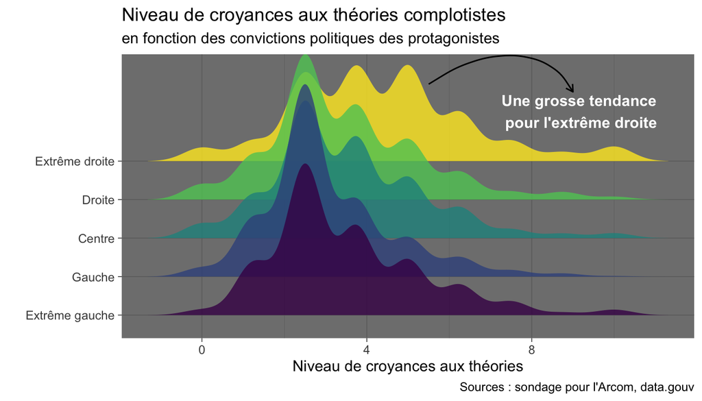

# **Conclusion**